# Supporting information for "Full vector low-temperature magnetic measurements of geologic materials"

## Experiments on PW10-7d

### NRM demagnetization

```python
PW10_7a_demag = pd.read_csv('../Data/Umkondo/PW10/PW10-7a.csv')
PW10_7a_demag
```

|  | specimen | step | intensity | dec_geo | inc_geo | dec_spec | inc_spec |
| --- | --- | --- | --- | --- | --- | --- | --- |
| 0 | PW10-7a | 0.0 | 0.001106 | 287.293 | 58.389400 | 131.3 | 49.4 |
| 1 | PW10-7a | 0.0 | 0.000362 | 205.501 | 25.299800 | 331.1 | 65.1 |
| 2 | PW10-7a | 1.0 | 0.000366 | 204.858 | 24.588300 | 330.4 | 64.2 |
| 3 | PW10-7a | 1.5 | 0.000369 | 204.310 | 23.822200 | 330.0 | 63.3 |
| 4 | PW10-7a | 2.0 | 0.000372 | 203.611 | 22.952500 | 329.4 | 62.3 |
| 5 | PW10-7a | 2.5 | 0.000375 | 202.734 | 21.649100 | 328.9 | 60.8 |
| 6 | PW10-7a | 5.0 | 0.000385 | 197.607 | 13.624400 | 326.2 | 51.5 |
| 7 | PW10-7a | 7.5 | 0.000348 | 192.869 | 6.610280 | 323.9 | 43.2 |
| 8 | PW10-7a | 10.0 | 0.000276 | 186.925 | 0.377430 | 320.2 | 35.1 |
| 9 | PW10-7a | 15.0 | 0.000214 | 184.698 | -2.601010 | 319.3 | 31.4 |
| 10 | PW10-7a | 20.0 | 0.000190 | 187.394 | -1.962070 | 321.9 | 33.2 |
| 11 | PW10-7a | 25.0 | 0.000170 | 189.228 | -1.561390 | 323.7 | 34.3 |
| 12 | PW10-7a | 30.0 | 0.000163 | 189.053 | -1.088220 | 323.3 | 34.6 |
| 13 | PW10-7a | 40.0 | 0.000145 | 186.617 | 4.399750 | 317.7 | 38.6 |
| 14 | PW10-7a | 50.0 | 0.000141 | 184.853 | 0.728249 | 317.8 | 34.5 |

```python
PW10_7a_datablock_geo=[]
PW10_7a_datablock_spec=[]
PW10_7a_DI_geo=[]
PW10_7a_DI_spec=[]
for n in range(0,len(PW10_7a_demag)):
    PW10_7a_datablock_geo.append([PW10_7a_demag['step'][n],
                                  PW10_7a_demag['dec_geo'][n],
                                  PW10_7a_demag['inc_geo'][n],
                                  PW10_7a_demag['intensity'][n]])
    PW10_7a_datablock_spec.append([PW10_7a_demag['step'][n],
                                  PW10_7a_demag['dec_spec'][n],
                                  PW10_7a_demag['inc_spec'][n],
                                  PW10_7a_demag['intensity'][n]])
    PW10_7a_DI_geo.append([PW10_7a_demag['dec_geo'][n],
                           PW10_7a_demag['inc_geo'][n]])
    PW10_7a_DI_spec.append([PW10_7a_demag['dec_spec'][n],
                            PW10_7a_demag['inc_spec'][n]])
```

#### Intensity plot

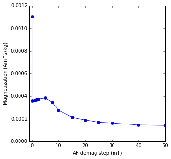

```
The remanence lost (in %) following low-temp cycling is:
67.2532472231
```

```python
plt.figure(figsize=(5,5))
plt.plot(PW10_7a_demag['step'],PW10_7a_demag['intensity'],marker='o')
plt.xlabel('AF demag step (mT)')
plt.ylabel('Magnetization (Am^2/kg)')
plt.xlim((-1,50))
plt.show()

print 'The remanence lost (in %) following low-temp cycling is:'
print ((PW10_7a_demag['intensity'][0]-PW10_7a_demag['intensity'][1])/PW10_7a_demag['intensity'][0])*100
```

The large loss of remanence is associated with the 77K nitrogen bath.

#### Plots in geographic coordinates

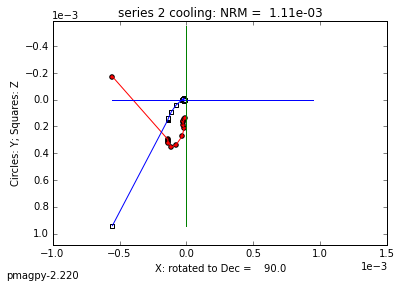

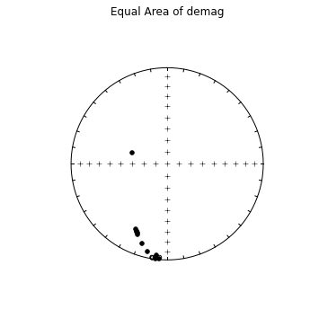

```python
#plot with pmagplotlib.plotZ(fignum,datablock,angle,s,norm)
pmagplotlib.plotZ(1,PW10_7a_datablock_geo,90,'series 2 cooling',0)
plt.ticklabel_format(style='sci', scilimits=(0,0), axis='y')
plt.ticklabel_format(style='sci', scilimits=(0,0), axis='x')
plt.show()

plt.figure(figsize=(5,5))
pmagplotlib.plotNET(1)
IPmag.iplotDI(PW10_7a_DI_geo)
plt.title('Equal Area of demag')
plt.show()
```

In the plots above, the large directional change and reduction in magnetization accompanies a low-temperature demagnetization step (i.e. 77 K nitrogen bath in a very low-field environment). Along with the following AF steps an overprint is removed that brings the data to the shallow southerly pointing vector which is consistent with other data from the ~1100 Ma Umkondo large igneous province.

```python
print "The angular change (in degrees) associated with the LTD step is:"
print pmag.angle(PW10_7a_DI_geo[0],PW10_7a_DI_geo[1])
```

```
The angular change (in degrees) associated with the LTD step is:
[ 64.43078671]
```

#### Specimen coordinates

These data plotted in specimen coordinates are more directly comparable to the data acquired on another specimen from the same sample using the IRM-LTI.

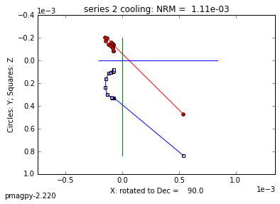

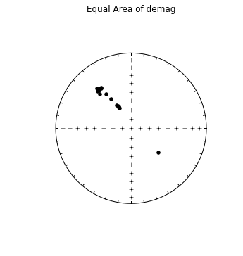

```python
#plot with pmagplotlib.plotZ(fignum,datablock,angle,s,norm)
pmagplotlib.plotZ(1,PW10_7a_datablock_spec,90,'series 2 cooling',0)
plt.ticklabel_format(style='sci', scilimits=(0,0), axis='y')
plt.ticklabel_format(style='sci', scilimits=(0,0), axis='x')
plt.savefig('code_output/Umk_Pw10-7a_specimen_zplot.pdf')
plt.show()

plt.figure(figsize=(5,5))
pmagplotlib.plotNET(1)
IPmag.iplotDI(PW10_7a_DI_spec)
plt.title('Equal Area of demag')
plt.savefig('code_output/Umk_Pw10-7a_specimen_eqaplot.pdf')
plt.show()
```

### MPMS experiments

```python
PW10_MPMS=pd.read_csv('../Data/Umkondo/PW10/PW10_7c_MPMS.csv',header=2)
pd.set_option('display.max_columns', None)
PW10_MPMS.head(5)
```

|  | T [K] | Bapp [T] | M [Am2/kg] | reg fit | timestamp | Unnamed: 5 | T [K].1 | Bapp [T].1 | M [Am2/kg].1 | reg fit.1 | timestamp.1 | Unnamed: 11 | T [K].2 | Bapp [T].2 | M [Am2/kg].2 | reg fit.2 | timestamp.2 | Unnamed: 17 | T [K].3 | Bapp [T].3 | M [Am2/kg].3 | reg fit.3 | timestamp.3 | Unnamed: 23 | T [K].4 | Bapp [T].4 | M [Am2/kg].4 | reg fit.4 | timestamp.4 |
| --- | --- | --- | --- | --- | --- | --- | --- | --- | --- | --- | --- | --- | --- | --- | --- | --- | --- | --- | --- | --- | --- | --- | --- | --- | --- | --- | --- | --- | --- |
| 0 | 299.9879 | 2.5 | 2.885055 | 0.990173 | 2/5/2013 4:13:32 PM | NaN | 19.99881 | 0 | 0.457038 | 0.990071 | 2/5/2013 5:27:50 PM | NaN | 19.99765 | 0 | 0.483920 | 0.988106 | 2/5/2013 7:43:34 PM | NaN | 300.0001 | 0 | 0.292515 | 0.989795 | 2/5/2013 8:53:56 PM | NaN | 19.99720 | 0 | 0.044147 | 0.987200 | 2/5/2013 10:03:51 PM |
| 1 | 294.2503 | 2.5 | 2.899802 | 0.989840 | 2/5/2013 4:16:42 PM | NaN | 25.59370 | 0 | 0.434746 | 0.989292 | 2/5/2013 5:29:09 PM | NaN | 25.55709 | 0 | 0.465696 | 0.987919 | 2/5/2013 7:44:54 PM | NaN | 294.4174 | 0 | 0.292170 | 0.989635 | 2/5/2013 8:56:51 PM | NaN | 25.65808 | 0 | 0.044205 | 0.987814 | 2/5/2013 10:05:12 PM |
| 2 | 288.9702 | 2.5 | 2.914910 | 0.989691 | 2/5/2013 4:17:28 PM | NaN | 30.62943 | 0 | 0.415489 | 0.989056 | 2/5/2013 5:30:10 PM | NaN | 30.55221 | 0 | 0.451775 | 0.988061 | 2/5/2013 7:45:55 PM | NaN | 289.0140 | 0 | 0.291212 | 0.989510 | 2/5/2013 8:57:42 PM | NaN | 30.53962 | 0 | 0.044195 | 0.987583 | 2/5/2013 10:06:11 PM |
| 3 | 283.9853 | 2.5 | 2.931989 | 0.989543 | 2/5/2013 4:18:06 PM | NaN | 35.51034 | 0 | 0.401149 | 0.988457 | 2/5/2013 5:31:10 PM | NaN | 35.59132 | 0 | 0.442285 | 0.987936 | 2/5/2013 7:46:57 PM | NaN | 283.8555 | 0 | 0.290107 | 0.989398 | 2/5/2013 8:58:22 PM | NaN | 35.66172 | 0 | 0.044043 | 0.987072 | 2/5/2013 10:07:14 PM |
| 4 | 278.9876 | 2.5 | 2.951009 | 0.989169 | 2/5/2013 4:18:40 PM | NaN | 40.58522 | 0 | 0.389925 | 0.988874 | 2/5/2013 5:32:11 PM | NaN | 40.54948 | 0 | 0.434388 | 0.988107 | 2/5/2013 7:47:56 PM | NaN | 279.0740 | 0 | 0.288958 | 0.989000 | 2/5/2013 8:58:58 PM | NaN | 40.49764 | 0 | 0.043838 | 0.987979 | 2/5/2013 10:08:12 PM |

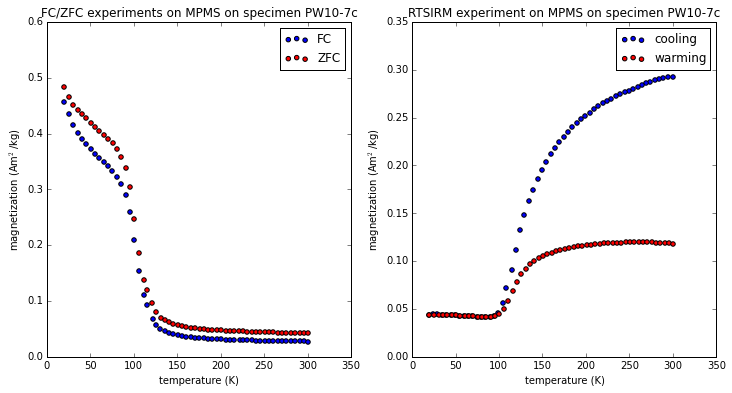

```python
fig=plt.figure(figsize=(12,6),dpi=160)
ax1 = fig.add_subplot(1, 2, 1)
ax2 = fig.add_subplot(1, 2, 2)
ax1.scatter(PW10_MPMS['T [K].1'],PW10_MPMS['M [Am2/kg].1'], c='b', label='FC')
ax1.scatter(PW10_MPMS['T [K].2'],PW10_MPMS['M [Am2/kg].2'], c='r', label='ZFC')
ax2.scatter(PW10_MPMS['T [K].3'],PW10_MPMS['M [Am2/kg].3'], c='b', label='cooling')
ax2.scatter(PW10_MPMS['T [K].4'],PW10_MPMS['M [Am2/kg].4'], c='r', label='warming')
ax1.set_xlabel('temperature (K)')
ax1.set_ylabel('magnetization (Am$^2$/kg)')
ax1.legend()
ax1.set_title('FC/ZFC experiments on MPMS on specimen PW10-7c')
ax2.set_xlabel('temperature (K)')
ax2.set_ylabel('magnetization (Am$^2$/kg)')
ax2.legend()
ax2.set_title('RTSIRM experiment on MPMS on specimen PW10-7c')
plt.savefig('code_output/PW10-7c_MPMS.svg')
plt.show()
```

### IRM-LTI experiments

#### Experiment on 07/21/2013 on specimen PW10-7d (measurement series 1 and 2):

This experiment was designed to be low-temperature cycling of the specimens natural remanent magnetization (NRM).

1. Load the sample with arrow (down core z-axis) pointing out of SRM (old 2G at IRM) and make measurement (measurement series #1, measurement #1,2,3,4). The direction should be approx. the same as the measurement of the sister "a-series" specimen.
2. Twist the sample screw tight as is needed for running in low-temperature insert which results in sample being rotated about the z-axis (measurement series #1, measurement #5).
3. Cover the sample holder with the sapphire radiation shield and vacuum shroud ((measurement series #1, measurement #5) and then begin cooling. Measurements are made upon cooling (measurement series #2).
4. Once at minimum temperature (slightly below 20K) warm the probe back up progressively making measurements as it warms (measurement series #2).

Import data file which has the format:

| TEMPERATURE (K) | M_x [Am2] | M_y [Am2] | M_z [Am2] | M_total [Am2] | MEASUREMENT SERIES |
| --- | --- | --- | --- | --- | --- |

```python
data_file='../Data/Umkondo/PW10/PW10-7d_rotation.txt'
data = np.genfromtxt(data_file, skip_header=1)

temp=data[:,0]
Mx=data[:,1]
My=data[:,2]
Mz=data[:,3]
Mtotal=data[:,4]
```

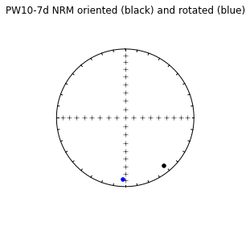

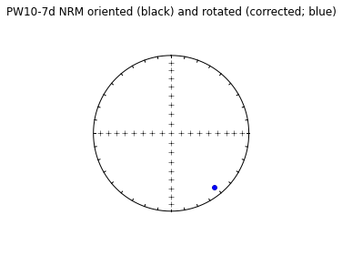

```python
full_vector_oriented=[]
full_vector_rotated=[]

#data point 3 is oriented (remember python starts at 0)
for n in range(3,4):
    Mx_full,My_full,Mz_full=Mx[n],My[n],Mz[n]
    full_vector_oriented.append([Mx_full,My_full,Mz_full])

#data point 4 is rotated about z (remember python starts at 0)
for n in range(4,5):
    Mx_full,My_full,Mz_full=Mx[n],My[n],Mz[n]
    full_vector_rotated.append([Mx_full,My_full,Mz_full])

oriented_directions=pmag.cart2dir(full_vector_oriented)
rotated_directions=pmag.cart2dir(full_vector_rotated)

#rotate rotated directions about the z-axis to correspond to the oriented measurement
angle = 360 + oriented_directions.item(0) - rotated_directions.item(0)

x_prime = Mx[4]*np.cos(np.radians(angle)) - My[4]*np.sin(np.radians(angle))
y_prime = Mx[4]*np.sin(np.radians(angle)) + My[4]*np.cos(np.radians(angle))
z_prime = Mz[4]

full_vector_rotated_prime= [[x_prime,y_prime,z_prime]]
rotated_directions_prime=pmag.cart2dir(full_vector_rotated_prime)

#plot the oriented measurement and the rotated measurement
fignum = 1
plt.figure(num=fignum,figsize=(4,4))
pmagplotlib.plotNET(fignum)
IPmag.iplotDI(oriented_directions,'k')
IPmag.iplotDI(rotated_directions,'b')
plt.title('PW10-7d NRM oriented (black) and rotated (blue)');

#plot the oriented measurement and the corrected rotated measurement
fignum = 2
plt.figure(num=fignum,figsize=(4,4))
pmagplotlib.plotNET(fignum)
IPmag.iplotDI(oriented_directions,'k')
IPmag.iplotDI(rotated_directions_prime,'b')
plt.title('PW10-7d NRM oriented (black) and rotated (corrected; blue)');
```

```python
data_file_cooling='../Data/Umkondo/PW10/PW10-7d_cooling.txt'
data_cooling = np.genfromtxt(data_file_cooling, skip_header=1)

temp_cooling=data_cooling[:,0]
Mx_cooling=data_cooling[:,1]
My_cooling=data_cooling[:,2]
Mz_cooling=data_cooling[:,3]
Mtotal_cooling=data_cooling[:,4]

data_file_warming='../Data/Umkondo/PW10/PW10-7d_warming.txt'
data_warming = np.genfromtxt(data_file_warming, skip_header=1)

temp_warming=data_warming[:,0]
Mx_warming=data_warming[:,1]
My_warming=data_warming[:,2]
Mz_warming=data_warming[:,3]
Mtotal_warming=data_warming[:,4]
```

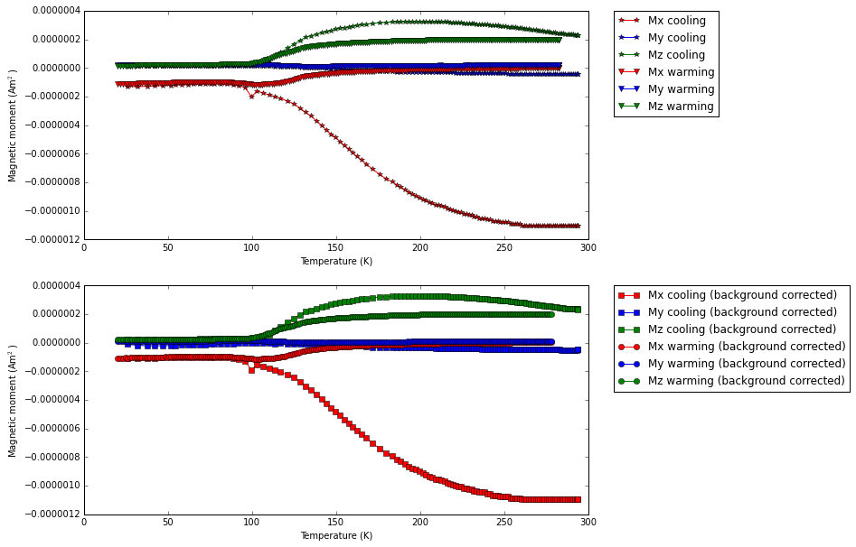

```python
Mx_cooling_bsub = background_sub(blank1_data_cooling['Mx[Am2]'],
                                 blank1_data_cooling['measurement_T[K]'],
                                 Mx_cooling,temp_cooling)

My_cooling_bsub = background_sub(blank1_data_cooling['My[Am2]'],
                                 blank1_data_cooling['measurement_T[K]'],
                                 My_cooling,temp_cooling)

Mz_cooling_bsub = background_sub(blank1_data_cooling['Mz[Am2]'],
                                 blank1_data_cooling['measurement_T[K]'],
                                 Mz_cooling,temp_cooling)

Mx_warming_bsub = background_sub(blank1_data_warming['Mx[Am2]'],
                                 blank1_data_warming['measurement_T[K]'],
                                 Mx_warming[:-8],temp_warming[:-8])

My_warming_bsub = background_sub(blank1_data_warming['My[Am2]'],
                                 blank1_data_warming['measurement_T[K]'],
                                 My_warming[:-8],temp_warming[:-8])

Mz_warming_bsub = background_sub(blank1_data_warming['Mz[Am2]'],
                                 blank1_data_warming['measurement_T[K]'],
                                 Mz_warming[:-8],temp_warming[:-8])

fignum=1
plt.figure(num=fignum,figsize=(10,10),dpi=160)

ax=plt.subplot(211)
plt.plot(temp_cooling, Mx_cooling, 'r*-',label="Mx cooling")
plt.plot(temp_cooling, My_cooling, 'b*-',label="My cooling")
plt.plot(temp_cooling, Mz_cooling, 'g*-',label="Mz cooling")
plt.plot(temp_warming, Mx_warming, 'rv-',label="Mx warming")
plt.plot(temp_warming, My_warming, 'bv-',label="My warming")
plt.plot(temp_warming, Mz_warming, 'gv-',label="Mz warming")
plt.xlabel('Temperature (K)')
plt.ylabel('Magnetic moment (Am$^2$)')
plt.legend(bbox_to_anchor=(1.05, 1), loc=2, borderaxespad=0.)

ax=plt.subplot(212)
plt.plot(temp_cooling, Mx_cooling_bsub, 'rs-',
         label="Mx cooling (background corrected)")
plt.plot(temp_cooling, My_cooling_bsub, 'bs-',
         label="My cooling (background corrected)")
plt.plot(temp_cooling, Mz_cooling_bsub, 'gs-',
         label="Mz cooling (background corrected)")
plt.plot(temp_warming[:-8], Mx_warming_bsub, 'ro-',
         label="Mx warming (background corrected)")
plt.plot(temp_warming[:-8], My_warming_bsub, 'bo-',
         label="My warming (background corrected)")
plt.plot(temp_warming[:-8], Mz_warming_bsub, 'go-',
         label="Mz warming (background corrected)")
plt.xlabel('Temperature (K)')
plt.ylabel('Magnetic moment (Am$^2$)')
plt.legend(bbox_to_anchor=(1.05, 1), loc=2, borderaxespad=0.)
plt.show()
```

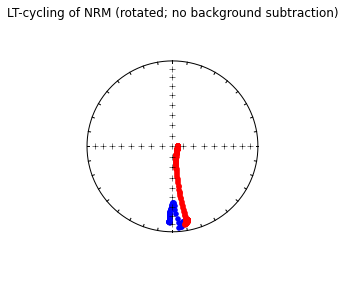

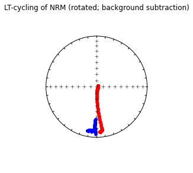

```python
full_vector_cooling=[]
for n in range(0,len(temp_cooling)):
    full_vector_cooling.append([Mx_cooling[n],My_cooling[n],Mz_cooling[n]])
full_vector_warming=[]
for n in range(0,len(temp_warming)):
    full_vector_warming.append([Mx_warming[n],My_warming[n],Mz_warming[n]])

cooling_directions=pmag.cart2dir(full_vector_cooling)
warming_directions=pmag.cart2dir(full_vector_warming)

fignum=3
plt.figure(num=fignum,figsize=(4,4),dpi=160)
pmagplotlib.plotNET(fignum)
IPmag.iplotDI(cooling_directions,'b')
IPmag.iplotDI(warming_directions,'r')
plt.title('LT-cycling of NRM (rotated; no background subtraction)')
#plt.savefig('PW10-7d_3axisLTD_eqarea.svg')
plt.show()

full_vector_cooling=[]
for n in range(0,len(temp_cooling)):
    full_vector_cooling.append([Mx_cooling_bsub[n],My_cooling_bsub[n],Mz_cooling_bsub[n]])
full_vector_warming=[]
for n in range(0,len(Mx_warming_bsub)):
    full_vector_warming.append([Mx_warming_bsub[n],My_warming_bsub[n],Mz_warming_bsub[n]])

cooling_directions=pmag.cart2dir(full_vector_cooling)
warming_directions=pmag.cart2dir(full_vector_warming)

fignum=3
plt.figure(num=fignum,figsize=(4,4),dpi=160)
pmagplotlib.plotNET(fignum)
IPmag.iplotDI(cooling_directions,'b')
IPmag.iplotDI(warming_directions,'r')
plt.title('LT-cycling of NRM (rotated; background subtraction)')
#plt.savefig('PW10-7d_3axisLTD_eqarea.svg')
plt.show()
```

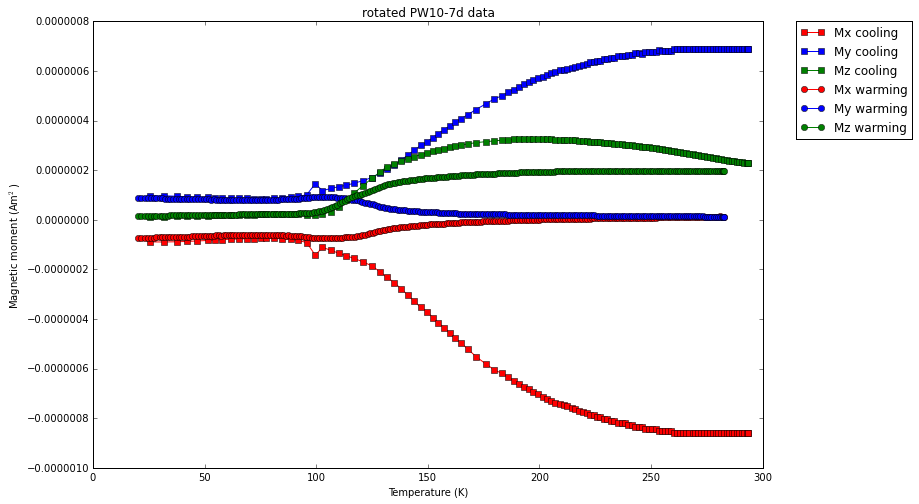

```python
Mx_cooling_prime = Mx_cooling*np.cos(np.radians(angle)) - My_cooling*np.sin(np.radians(angle))
My_cooling_prime = Mx_cooling*np.sin(np.radians(angle)) + My_cooling*np.cos(np.radians(angle))
Mz_cooling_prime = Mz_cooling
full_vector_cooling=[]
for n in range(0,len(temp_cooling)):
    full_vector_cooling.append([Mx_cooling_prime[n],My_cooling_prime[n],Mz_cooling_prime[n]])

Mx_warming_prime = Mx_warming*np.cos(np.radians(angle)) - My_warming*np.sin(np.radians(angle))
My_warming_prime = Mx_warming*np.sin(np.radians(angle)) + My_warming*np.cos(np.radians(angle))
Mz_warming_prime = Mz_warming
full_vector_warming=[]
for n in range(0,len(temp_warming)):
    full_vector_warming.append([Mx_warming_prime[n],My_warming_prime[n],Mz_warming_prime[n]])

fignum=2
plt.figure(num=fignum,figsize=(12,8),dpi=160)
plt.plot(temp_cooling, Mx_cooling_prime, 'rs-',label="Mx cooling")
plt.plot(temp_cooling, My_cooling_prime, 'bs-',label="My cooling")
plt.plot(temp_cooling, Mz_cooling_prime, 'gs-',label="Mz cooling")
plt.plot(temp_warming, Mx_warming_prime, 'ro-',label="Mx warming")
plt.plot(temp_warming, My_warming_prime, 'bo-',label="My warming")
plt.plot(temp_warming, Mz_warming_prime, 'go-',label="Mz warming")
plt.legend(bbox_to_anchor=(1.05, 1), loc=2, borderaxespad=0.)
plt.xlabel('Temperature (K)')
plt.ylabel('Magnetic moment (Am$^2$)')
plt.title('rotated PW10-7d data')
plt.savefig('code_output/PW10-7d_3axisLTD.svg')
```

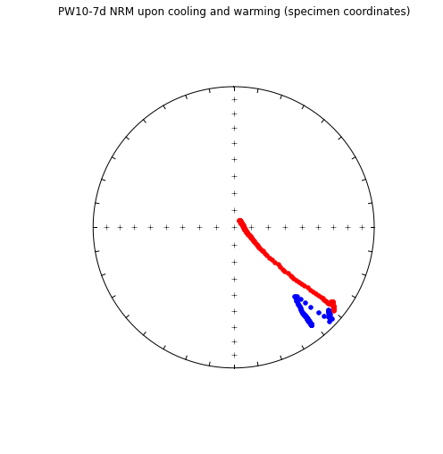

```python
cooling_directions=pmag.cart2dir(full_vector_cooling)
warming_directions=pmag.cart2dir(full_vector_warming)

fignum=3
plt.figure(num=fignum,figsize=(7,7),dpi=160)
pmagplotlib.plotNET(fignum)
IPmag.iplotDI(cooling_directions,'b')
IPmag.iplotDI(warming_directions,'r')
plt.title('PW10-7d NRM upon cooling and warming (specimen coordinates)')
plt.savefig('code_output/PW10-7d_3axisLTD_eqarea.svg')
plt.show()
```

```python
print "The angular change from NRM to the end of LT-cycling is:"
print pmag.angle(cooling_directions[0],warming_directions[240])
```

```
The angular change from NRM to the end of LT-cycling is:
[ 84.7946601]
```

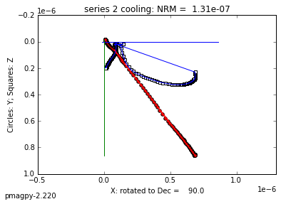

```python
PW10_7d_datablock=[]

for n in range(0,len(cooling_directions)):
    PW10_7d_datablock.append([temp_cooling[n],
                              cooling_directions[n][0],
                              cooling_directions[n][1],
                              cooling_directions[n][2]])
for n in range(0,len(warming_directions)):
    PW10_7d_datablock.append([temp_warming[n],
                              warming_directions[n][0],
                              warming_directions[n][1],
                              warming_directions[n][2]])

#plot with pmagplotlib.plotZ(fignum,datablock,angle,s,norm)
pmagplotlib.plotZ(1,PW10_7d_datablock,90,'series 2 cooling',0)
plt.ticklabel_format(style='sci', scilimits=(0,0), axis='y')
plt.ticklabel_format(style='sci', scilimits=(0,0), axis='x')
plt.savefig('code_output/Umk_Pw10-7a_specimen_zplot.pdf')
plt.show()
```

## PW15-4

This sample is from the interior (~ 11 meters from margin) of an Umkondo Large Igneous Province diabase sill (the Mogatelwane 2 sill) and displayed a large loss in remanence associated with a liquid nitrogen treatment step that was applied during initial demagnetization of the NRM. Due to this behavior the sample was targeted for experiments on the low-temperature probe.

### NRM demagnetization

```python
PW15_4a_demag = pd.read_csv('../Data/Umkondo/PW15/PW15-4a.csv')
PW15_4a_demag
```

|  | specimen | step(mT) | intensity | dec_geo | inc_geo | dec_spec | inc_spec |
| --- | --- | --- | --- | --- | --- | --- | --- |
| 0 | PW15-4 | 0 | 0.034587 | 200.2 | -7.8 | 354.3 | 72.1 |
| 1 | PW15-4 | 0 | 0.016562 | 200.1 | -9.1 | 354.2 | 70.8 |
| 2 | PW15-4 | 5 | 0.015866 | 200.1 | -8.8 | 354.3 | 71.1 |
| 3 | PW15-4 | 10 | 0.010725 | 199.8 | -8.1 | 352.9 | 71.7 |
| 4 | PW15-4 | 15 | 0.005063 | 198.5 | -9.9 | 349.8 | 69.8 |
| 5 | PW15-4 | 20 | 0.002243 | 196.5 | -12.2 | 346.0 | 67.2 |
| 6 | PW15-4 | 25 | 0.001239 | 194.6 | -11.6 | 341.1 | 67.2 |
| 7 | PW15-4 | 30 | 0.000706 | 194.5 | -11.6 | 340.7 | 67.1 |
| 8 | PW15-4 | 40 | 0.000372 | 194.5 | -12.4 | 341.4 | 66.4 |
| 9 | PW15-4 | 50 | 0.000212 | 194.1 | -13.3 | 341.2 | 65.4 |
| 10 | PW15-4 | 60 | 0.000135 | 193.5 | -14.0 | 340.5 | 64.6 |
| 11 | PW15-4 | 70 | 0.000090 | 192.0 | -12.6 | 336.1 | 65.3 |
| 12 | PW15-4 | 80 | 0.000075 | 192.5 | -15.6 | 339.6 | 62.7 |
| 13 | PW15-4 | 90 | 0.000058 | 192.7 | -11.5 | 336.4 | 66.6 |
| 14 | PW15-4 | 100 | 0.000046 | 188.5 | -10.8 | 326.9 | 65.3 |

```python
PW15_4a_datablock_geo=[]
PW15_4a_datablock_spec=[]
PW15_4a_DI_geo=[]
PW15_4a_DI_spec=[]
for n in range(0,len(PW15_4a_demag)):
    PW15_4a_datablock_geo.append([PW15_4a_demag['step(mT)'][n],
                                  PW15_4a_demag['dec_geo'][n],
                                  PW15_4a_demag['inc_geo'][n],
                                  PW15_4a_demag['intensity'][n]])
    PW15_4a_datablock_spec.append([PW15_4a_demag['step(mT)'][n],
                                  PW15_4a_demag['dec_spec'][n],
                                  PW15_4a_demag['inc_spec'][n],
                                  PW15_4a_demag['intensity'][n]])
    PW15_4a_DI_geo.append([PW15_4a_demag['dec_geo'][n],
                           PW15_4a_demag['inc_geo'][n]])
    PW15_4a_DI_spec.append([PW15_4a_demag['dec_spec'][n],
                            PW15_4a_demag['inc_spec'][n]])
```

#### Intensity plot

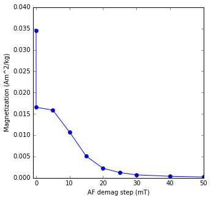

```
The remanence lost (in %) following low-temp cycling is:
52.116666763
```

```python
plt.figure(figsize=(5,5))
plt.plot(PW15_4a_demag['step(mT)'],PW15_4a_demag['intensity'],marker='o')
plt.xlabel('AF demag step (mT)')
plt.ylabel('Magnetization (Am^2/kg)')
plt.xlim((-1,50))
plt.ylim((0,.04))
plt.savefig('code_output/PW15_4a_intensity.pdf')
plt.show()

print 'The remanence lost (in %) following low-temp cycling is:'
print ((PW15_4a_demag['intensity'][0]-PW15_4a_demag['intensity'][1])/PW15_4a_demag['intensity'][0])*100
```

The large loss of remanence is associated with a low-temperature nitrogen bath in near-zero field.

#### Z-plot and equal area in specimen coordinates

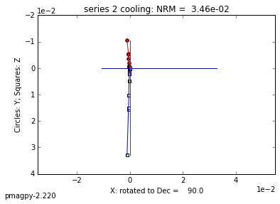

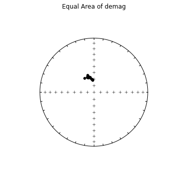

```python
#plot with pmagplotlib.plotZ(fignum,datablock,angle,s,norm)
pmagplotlib.plotZ(1,PW15_4a_datablock_spec,90,'series 2 cooling',0)
plt.ticklabel_format(style='sci', scilimits=(0,0), axis='y')
plt.ticklabel_format(style='sci', scilimits=(0,0), axis='x')
plt.savefig('code_output/PW15_4a_specimen_zplot.pdf')
plt.show()

plt.figure(figsize=(5,5))
pmagplotlib.plotNET(1)
IPmag.iplotDI(PW15_4a_DI_spec)
plt.title('Equal Area of demag')
plt.savefig('code_output/PW15_4a_specimen_eqaplot.pdf')
plt.show()
```

## IRM-LTI experiments

The experiments conducted on the samples were as follows.

1. Load the sample with arrow (down core z-axis) pointing out of SRM (old 2G at IRM) and make measurement (measurement series #1, measurement #1). The direction should be approx. the same as the measurement of the sister "a-series" specimen.
2. Twist the sample screw tight as is needed for running in low-temperature insert which results in sample being rotated about the z-axis (measurement series #1, measurement #2).
3. Cover the sample holder with the sapphire radiation shield and vacuum shroud and then being cooling. Measurements are made upon cooling (measurement series #2).
4. Once at minimum temperature (slightly below 20K) warm the probe back up progressively making measurements as it warms (measurement series #2).

### LT-cycling of NRM

Import data file which has the format:

| TEMPERATURE (K) | M_x [Am2] | M_y [Am2] | M_z [Am2] | M_total [Am2] | MEASUREMENT SERIES |
| --- | --- | --- | --- | --- | --- |

```python
PW15_data = pd.read_table('../Data/Umkondo/PW15/PW15-4d_LTI_experiments.txt')
PW15_data.head()
```

|  | measurement_T[K] | Mx[Am2] | My[Am2] | Mz[Am2] | moment[Am2] | Measurement_series |
| --- | --- | --- | --- | --- | --- | --- |
| 0 | 293.03 | 0.000007 | 0.000000 | 0.000024 | 0.000025 | 1 |
| 1 | 292.90 | -0.000002 | -0.000007 | 0.000024 | 0.000025 | 1 |
| 2 | 293.30 | -0.000002 | -0.000007 | 0.000024 | 0.000025 | 2 |
| 3 | 293.59 | -0.000002 | -0.000007 | 0.000024 | 0.000025 | 2 |
| 4 | 293.26 | -0.000002 | -0.000007 | 0.000024 | 0.000025 | 2 |

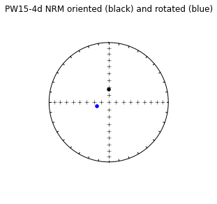

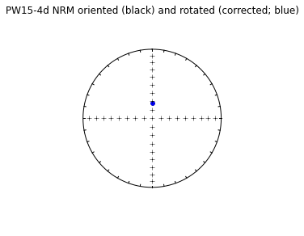

```python
full_vector_oriented=[]
full_vector_rotated=[]

#data point 0 is oriented
for n in range(0,1):
    full_vector_oriented.append([PW15_data['Mx[Am2]'][n],
                                 PW15_data['My[Am2]'][n],
                                 PW15_data['Mz[Am2]'][n]])

#data point 1 is rotated about z
for n in range(1,2):
    full_vector_rotated.append([PW15_data['Mx[Am2]'][n],
                                PW15_data['My[Am2]'][n],
                                PW15_data['Mz[Am2]'][n]])


oriented_directions=pmag.cart2dir(full_vector_oriented)
rotated_directions=pmag.cart2dir(full_vector_rotated)

#rotate the rotated directions about the z-axis
#to correspond to the oriented measurement
angle = 360 + oriented_directions.item(0) - rotated_directions.item(0)

x_prime = PW15_data['Mx[Am2]'][1]*np.cos(np.radians(angle)) - PW15_data['My[Am2]'][1]*np.sin(np.radians(angle))
y_prime = PW15_data['Mx[Am2]'][1]*np.sin(np.radians(angle)) + PW15_data['My[Am2]'][1]*np.cos(np.radians(angle))
z_prime = PW15_data['Mz[Am2]'][1]

full_vector_rotated_prime= [[x_prime,y_prime,z_prime]]
rotated_directions_prime=pmag.cart2dir(full_vector_rotated_prime)

#plot the oriented measurement and the rotated measurement
fignum = 1
plt.figure(num=fignum,figsize=(4,4),dpi=160)
pmagplotlib.plotNET(fignum)
IPmag.iplotDI(oriented_directions,'k')
IPmag.iplotDI(rotated_directions,'b')
plt.title('PW15-4d NRM oriented (black) and rotated (blue)');

#plot the oriented measurement and the corrected rotated measurement
fignum = 2
plt.figure(num=fignum,figsize=(4,4),dpi=160)
pmagplotlib.plotNET(fignum)
IPmag.iplotDI(oriented_directions,'k')
IPmag.iplotDI(rotated_directions_prime,'b')
plt.title('PW15-4d NRM oriented (black) and rotated (corrected; blue)');
```

It will be more convenient to have the data for measurement series 2 (LT-cycling) split into cooling and warming.

```python
PW15_s2_cooling = PW15_data[2:121]
PW15_s2_cooling.reset_index(inplace='True')
PW15_s2_warming = PW15_data[129:374]
PW15_s2_warming.reset_index(inplace='True')

PW15_s2_warming.tail()
```

|  | index | measurement_T[K] | Mx[Am2] | My[Am2] | Mz[Am2] | moment[Am2] | Measurement_series |
| --- | --- | --- | --- | --- | --- | --- | --- |
| 240 | 369 | 284.16 | -0.000001 | -0.000003 | 0.000012 | 0.000013 | 2 |
| 241 | 370 | 284.47 | -0.000001 | -0.000003 | 0.000012 | 0.000013 | 2 |
| 242 | 371 | 284.39 | -0.000001 | -0.000003 | 0.000012 | 0.000013 | 2 |
| 243 | 372 | 284.46 | -0.000001 | -0.000003 | 0.000012 | 0.000013 | 2 |
| 244 | 373 | 284.52 | -0.000001 | -0.000003 | 0.000012 | 0.000013 | 2 |

The data need to be rotated into the oriented specimen coordinates. These rotated data will be called 'prime'.

```python
PW15_s2_cooling['Mx_prime[Am2]'] = PW15_s2_cooling['Mx[Am2]']*np.cos(np.radians(angle)) - PW15_s2_cooling['My[Am2]']*np.sin(np.radians(angle))
PW15_s2_cooling['My_prime[Am2]'] = PW15_s2_cooling['Mx[Am2]']*np.sin(np.radians(angle)) + PW15_s2_cooling['My[Am2]']*np.cos(np.radians(angle))
PW15_s2_cooling['Mz_prime[Am2]'] = PW15_s2_cooling['Mz[Am2]']

full_vector_cooling_prime=[]
for n in range(len(PW15_s2_cooling)):
    full_vector_cooling_prime.append([PW15_s2_cooling['Mx_prime[Am2]'][n],
                                      PW15_s2_cooling['My_prime[Am2]'][n],
                                      PW15_s2_cooling['Mz_prime[Am2]'][n]])

PW15_s2_warming['Mx_prime[Am2]'] = PW15_s2_warming['Mx[Am2]']*np.cos(np.radians(angle)) - PW15_s2_warming['My[Am2]']*np.sin(np.radians(angle))
PW15_s2_warming['My_prime[Am2]'] = PW15_s2_warming['Mx[Am2]']*np.sin(np.radians(angle)) + PW15_s2_warming['My[Am2]']*np.cos(np.radians(angle))
PW15_s2_warming['Mz_prime[Am2]'] = PW15_s2_warming['Mz[Am2]']

full_vector_warming_prime=[]
for n in range(len(PW15_s2_warming)):
    full_vector_warming_prime.append([PW15_s2_warming['Mx_prime[Am2]'][n],
                                      PW15_s2_warming['My_prime[Am2]'][n],
                                      PW15_s2_warming['Mz_prime[Am2]'][n]])
```

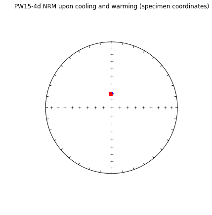

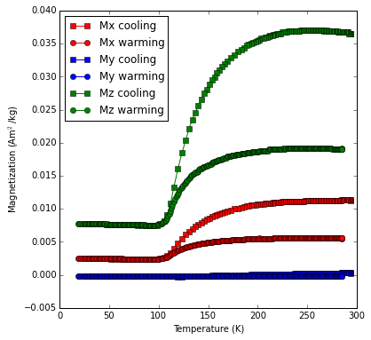

```python
cooling_directions_prime=pmag.cart2dir(full_vector_cooling_prime)
warming_directions_prime=pmag.cart2dir(full_vector_warming_prime)

fignum=1
plt.figure(num=fignum,figsize=(6,6),dpi=160)
pmagplotlib.plotNET(fignum)
IPmag.iplotDI(cooling_directions_prime,'b')
IPmag.iplotDI(warming_directions_prime,'r')
plt.title('PW15-4d NRM upon cooling and warming (specimen coordinates)')
plt.savefig('code_output/PW15-4d_equalarea.pdf')
plt.show()

#the specimen has a mass of .6483 g
fignum=2
plt.figure(num=fignum,figsize=(6,6),dpi=160)
plt.plot(PW15_s2_cooling['measurement_T[K]'],
         PW15_s2_cooling['Mx_prime[Am2]']/(.6483/1000), 'rs-')
plt.plot(PW15_s2_warming['measurement_T[K]'],
         PW15_s2_warming['Mx_prime[Am2]']/(.6483/1000), 'ro-')
plt.plot(PW15_s2_cooling['measurement_T[K]'],
         PW15_s2_cooling['My_prime[Am2]']/(.6483/1000), 'bs-')
plt.plot(PW15_s2_warming['measurement_T[K]'],
         PW15_s2_warming['My_prime[Am2]']/(.6483/1000), 'bo-')
plt.plot(PW15_s2_cooling['measurement_T[K]'],
         PW15_s2_cooling['Mz_prime[Am2]']/(.6483/1000), 'gs-')
plt.plot(PW15_s2_warming['measurement_T[K]'],
         PW15_s2_warming['Mz_prime[Am2]']/(.6483/1000), 'go-')
plt.xlabel('Temperature (K)')
plt.ylabel('Magnetization (Am$^2$/kg)')
plt.legend(('Mx cooling','Mx warming','My cooling',
            'My warming','Mz cooling','Mz warming'),loc=0)
plt.savefig('code_output/PW15-4d_3axis.svg')
plt.show()
```

```python
moment_290 = cooling_directions_prime[1,2]
moment_20 = cooling_directions_prime[118,2]
moment_postcycle = warming_directions_prime[244,2]

print "Percent remanence remaining at 20K"
print moment_20/moment_290*100
print "Percent remanence remaining after thermal cycling"
print moment_postcycle/moment_290*100
```

```
Percent remanence remaining at 20K
21.234697426
Percent remanence remaining after thermal cycling
51.6463378548
```

### ARM/pARM acquisition and low-temperature cycling

This experiment was designed to impart an ARM to the sample and a perpendicular pARM (to low coercivities) to the sample in order to ascertain the behavior of the low-coercivity ARM and resolve directional change during low-temperature cycling.

1. Give the specimen a negative z-axis ARM (0.03 mT bias field in 200 mT AF field) and measure (measurement 1 in measurement series #3) (after the measurement the decision was made to increase the bias field in order to increase the moment)
2. Give the specimen a negative z-axis ARM (0.1 mT bias field in 200 mT AF field) and measure (measurement 2 in measurement series #3)
3. Give the specimen a negative x-axis ARM (0.1 mT bias field in 5 mT AF field) and measure (measurement 3 in measurement series #3) (after the measurement the decision was made to increase the of this pARM bias field in order to increase the moment)
4. Give the specimen a negative x-axis ARM (0.2 mT bias field in 5 mT AF field) and measure (measurement 4 in measurement series #3)
5. Tightening the sample holder for the cryogenic experiment requires rotating the sample an unknown amount about the z-axis (measurement 5 in measurement series #3)
6. Cover the sample holder with the sapphire radiation shield and vacuum shroud and then being cooling. Measurements are made upon cooling and subsequent warming (measurement series #4).

#### ARM/pARM acquisition

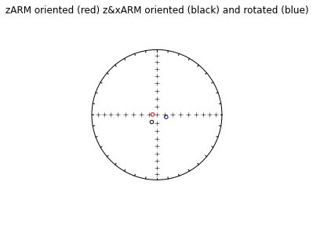

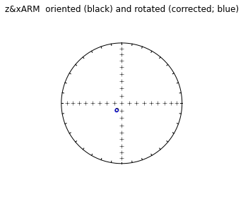

```python
zARM_oriented=[]
zARMxARM_oriented=[]
zARMxARM_rotated=[]

#negative z-axis ARM (0.1 mT bias field in 200 mT AF field)
for n in range(375,376):
    Mx_full=PW15_data['Mx[Am2]'][n]
    My_full=PW15_data['My[Am2]'][n]
    Mz_full=PW15_data['Mz[Am2]'][n]
    zARM_oriented.append([Mx_full,My_full,Mz_full])

#negative z-axis ARM (0.1 mT bias field in 200 mT AF field) + negative x-axis ARM (0.2 mT bias field in 5 mT AF field)
for n in range(377,378):
    Mx_full=PW15_data['Mx[Am2]'][n]
    My_full=PW15_data['My[Am2]'][n]
    Mz_full=PW15_data['Mz[Am2]'][n]
    zARMxARM_oriented.append([Mx_full,My_full,Mz_full])

#negative z-axis ARM (0.1 mT bias field in 200 mT AF field) + negative x-axis ARM (0.2 mT bias field in 5 mT AF field) rotated about z-axis
for n in range(378,379):
    Mx_full=PW15_data['Mx[Am2]'][n]
    My_full=PW15_data['My[Am2]'][n]
    Mz_full=PW15_data['Mz[Am2]'][n]
    zARMxARM_rotated.append([Mx_full,My_full,Mz_full])

zARM_oriented_directions=pmag.cart2dir(zARM_oriented)
zARMxARM_oriented_directions=pmag.cart2dir(zARMxARM_oriented)
zARMxARM_rotated_directions=pmag.cart2dir(zARMxARM_rotated)

#rotate the rotated directions about the z-axis to correspond to the oriented measurement
angle =  zARMxARM_oriented_directions.item(0) - zARMxARM_rotated_directions.item(0)

x_prime = PW15_data['Mx[Am2]'][378]*np.cos(np.radians(angle)) - PW15_data['My[Am2]'][378]*np.sin(np.radians(angle))
y_prime = PW15_data['Mx[Am2]'][378]*np.sin(np.radians(angle)) + PW15_data['My[Am2]'][378]*np.cos(np.radians(angle))
z_prime = PW15_data['Mz[Am2]'][378]

zARMxARM_rotated_prime = [[x_prime,y_prime,z_prime]]
zARMxARM_rotated_directions_prime=pmag.cart2dir(zARMxARM_rotated_prime)

#plot the oriented measurements and the rotated measurement
fignum = 1
plt.figure(num=fignum,figsize=(4,4),dpi=160)
pmagplotlib.plotNET(fignum)
IPmag.iplotDI(zARM_oriented_directions,'r')
IPmag.iplotDI(zARMxARM_oriented_directions,'k')
IPmag.iplotDI(zARMxARM_rotated_directions,'b')
plt.title('zARM oriented (red) z&xARM oriented (black) and rotated (blue)');
plt.savefig('code_output/PW15-4d_eqarea_ARMex.svg')

#plot the oriented measurement and the corrected rotated measurement
fignum = 2
plt.figure(num=fignum,figsize=(4,4),dpi=160)
pmagplotlib.plotNET(fignum)
IPmag.iplotDI(zARMxARM_oriented_directions,'k')
IPmag.iplotDI(zARMxARM_rotated_directions_prime,'b')
plt.title('z&xARM  oriented (black) and rotated (corrected; blue)');
```

```python
#these values were needed to plot with the low-temp cycling data
#on the vector component and equal area plot
print zARM_oriented_directions
print zARMxARM_rotated_directions_prime
```

```
[[  2.74201770e+02  -8.45885759e+01   7.45321764e-07]]
[[  2.15129124e+02  -7.80651803e+01   7.16487969e-07]]
```

#### Low-temperature cycling

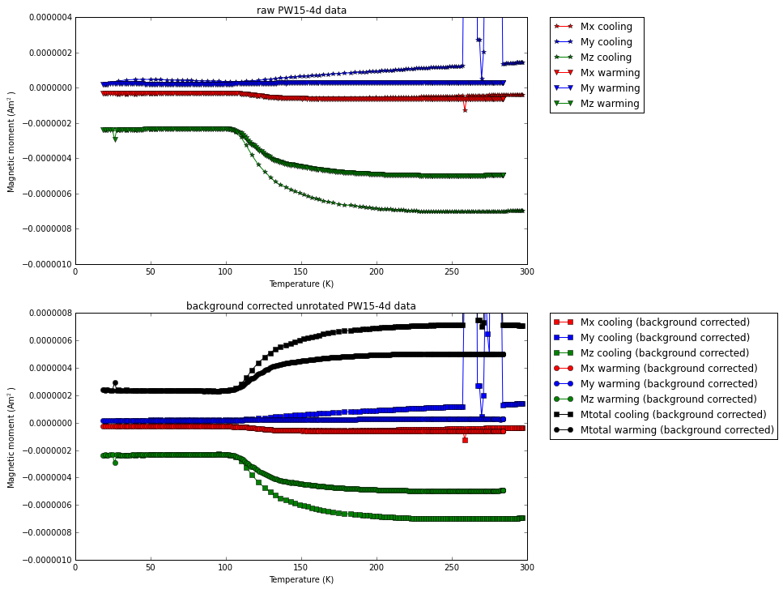

```python
data_file_cooling='../Data/Umkondo/PW15/Pw15-4d_ARMex_cooling.txt'
data_cooling = np.genfromtxt(data_file_cooling, skip_header=1)

temp_cooling=data_cooling[:,0]
Mx_cooling=data_cooling[:,1]
My_cooling=data_cooling[:,2]
Mz_cooling=data_cooling[:,3]
Mtotal_cooling=data_cooling[:,4]

data_file_warming='../Data/Umkondo/PW15/Pw15-4d_ARMex_warming.txt'
data_warming = np.genfromtxt(data_file_warming, skip_header=1)

temp_warming=data_warming[:,0]
Mx_warming=data_warming[:,1]
My_warming=data_warming[:,2]
Mz_warming=data_warming[:,3]
Mtotal_warming=data_warming[:,4]

#For the interpolate function to work the x values (temperature) need to be ascending.
#The blank_hem_data_cooling can be sorted so that temperatures are ascending
blank2_data_cooling = blank2_data_cooling.sort(['measurement_T[K]'])

Mx_cooling_bsub = background_sub(blank2_data_cooling['Mx[Am2]'],
                                 blank2_data_cooling['measurement_T[K]'],
                                 Mx_cooling,temp_cooling)

My_cooling_bsub = background_sub(blank2_data_cooling['My[Am2]'],
                                 blank2_data_cooling['measurement_T[K]'],
                                 My_cooling,temp_cooling)

Mz_cooling_bsub = background_sub(blank2_data_cooling['Mz[Am2]'],
                                 blank2_data_cooling['measurement_T[K]'],
                                 Mz_cooling,temp_cooling)

Mx_warming_bsub = background_sub(blank2_data_warming['Mx[Am2]'],
                                 blank2_data_warming['measurement_T[K]'],
                                 Mx_warming,temp_warming)

My_warming_bsub = background_sub(blank2_data_warming['My[Am2]'],
                                 blank2_data_warming['measurement_T[K]'],
                                 My_warming,temp_warming)

Mz_warming_bsub = background_sub(blank2_data_warming['Mz[Am2]'],
                                 blank2_data_warming['measurement_T[K]'],
                                 Mz_warming,temp_warming)

Mtotal_cooling_bsub=[]
Mtotal_warming_bsub=[]

for n in range(0,len(temp_cooling)):
    Mtotal_cooling_bsub.append(np.sqrt(Mx_cooling_bsub[n]**2+My_cooling_bsub[n]**2+Mz_cooling_bsub[n]**2))

for n in range(0,len(temp_warming)):
    Mtotal_warming_bsub.append(np.sqrt(Mx_warming_bsub[n]**2+My_warming_bsub[n]**2+Mz_warming_bsub[n]**2))

fignum=1
plt.figure(num=fignum,figsize=(10,12),dpi=160)

ax=plt.subplot(211)
plt.plot(temp_cooling, Mx_cooling, 'r*-',label="Mx cooling")
plt.plot(temp_cooling, My_cooling, 'b*-',label="My cooling")
plt.plot(temp_cooling, Mz_cooling, 'g*-',label="Mz cooling")
plt.plot(temp_warming, Mx_warming, 'rv-',label="Mx warming")
plt.plot(temp_warming, My_warming, 'bv-',label="My warming")
plt.plot(temp_warming, Mz_warming, 'gv-',label="Mz warming")
plt.xlabel('Temperature (K)')
plt.ylabel('Magnetic moment (Am$^2$)')
plt.axis([0, 300, -0.000001, 0.0000004])
plt.title('raw PW15-4d data')
plt.legend(bbox_to_anchor=(1.05, 1), loc=2, borderaxespad=0.)

ax=plt.subplot(212)
plt.plot(temp_cooling, Mx_cooling_bsub, 'rs-',
         label="Mx cooling (background corrected)")
plt.plot(temp_cooling, My_cooling_bsub, 'bs-',
         label="My cooling (background corrected)")
plt.plot(temp_cooling, Mz_cooling_bsub, 'gs-',
         label="Mz cooling (background corrected)")
plt.plot(temp_warming, Mx_warming_bsub, 'ro-',
         label="Mx warming (background corrected)")
plt.plot(temp_warming, My_warming_bsub, 'bo-',
         label="My warming (background corrected)")
plt.plot(temp_warming, Mz_warming_bsub, 'go-',
         label="Mz warming (background corrected)")
plt.plot(temp_cooling, Mtotal_cooling_bsub, 'ks-',
         label="Mtotal cooling (background corrected)")
plt.plot(temp_warming, Mtotal_warming_bsub, 'ko-',
         label="Mtotal warming (background corrected)")
plt.xlabel('Temperature (K)')
plt.ylabel('Magnetic moment (Am$^2$)')
plt.legend(bbox_to_anchor=(1.05, 1), loc=2, borderaxespad=0.)
plt.title('background corrected unrotated PW15-4d data')
plt.axis([0, 300, -0.000001, 0.0000008])
plt.show()
```

The fan turning on and off on another instrument in the lab resulted in flux jumps during a portion of time during initial cooling. These data need to be filtered out of the data set which is done below. The data also need to be rotated into the specimen's core coordinates.

```python
Mx_cooling_prime = Mx_cooling_bsub*np.cos(np.radians(angle)) - My_cooling_bsub*np.sin(np.radians(angle))
My_cooling_prime = Mx_cooling_bsub*np.sin(np.radians(angle)) + My_cooling_bsub*np.cos(np.radians(angle))
Mz_cooling_prime = Mz_cooling_bsub
Mx_cooling_prime_nf = []
My_cooling_prime_nf = []
Mz_cooling_prime_nf = []
Mtotal_cooling_prime_nf = []
full_vector_cooling=[]
temp_cooling_prime = []
temp_cooling_prime_nf = []

for n in range(0,len(temp_cooling)):
    if My_cooling[n] < 1.45000000e-07 and temp_cooling[n] != 269.77999999999997:
        #this filter is instituted to remove data points that are spurious due to flux jumps
        Mx_cooling_prime_nf.append(Mx_cooling_prime[n])
        My_cooling_prime_nf.append(My_cooling_prime[n])
        Mz_cooling_prime_nf.append(Mz_cooling_prime[n])
        temp_cooling_prime_nf.append(temp_cooling[n])
        Mtotal_cooling_prime_nf.append(np.sqrt(Mx_cooling_prime[n]**2+My_cooling_prime[n]**2+Mz_cooling_prime[n]**2))
        full_vector_cooling.append([Mx_cooling_prime[n],My_cooling_prime[n],Mz_cooling_prime[n]])

Mx_warming_prime = Mx_warming_bsub*np.cos(np.radians(angle)) - My_warming_bsub*np.sin(np.radians(angle))
My_warming_prime = Mx_warming_bsub*np.sin(np.radians(angle)) + My_warming_bsub*np.cos(np.radians(angle))
Mz_warming_prime = Mz_warming_bsub

Mtotal_warming_prime= []
full_vector_warming=[]

for n in range(0,len(temp_warming)):
    full_vector_warming.append([Mx_warming_prime[n],My_warming_prime[n],Mz_warming_prime[n]])
    Mtotal_warming_prime.append(np.sqrt(Mx_warming_prime[n]**2+My_warming_prime[n]**2+Mz_warming_prime[n]**2))
```

These rotated, background corrected data are plotted below along with data that shows the change in magnetocrystalline anisotropy as a function of temperature for the sake of comparision with the patterns of demagnetization observed for the z-axis component (full ARM up to 200 mT except 0 to 5 mT) and the x-axis pARM (applied to low coercivity grains with a 0 to 5 mT AF field).

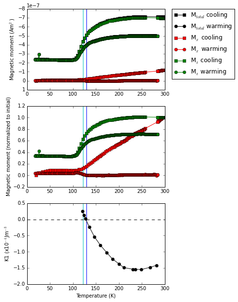

```python
fignum=2
plt.figure(num=fignum,figsize=(5,10),dpi=160)
ax=plt.subplot(311)
plt.plot(temp_cooling_prime_nf, np.negative(Mtotal_cooling_prime_nf),
         'ks-',label="M$_{total}$ cooling")
plt.plot(temp_warming, np.negative(Mtotal_warming_prime),
         'ko-',label="M$_{total}$ warming")
plt.plot(temp_cooling_prime_nf, Mx_cooling_prime_nf, 'rs-',label="M$_x$ cooling")
plt.plot(temp_warming, Mx_warming_prime, 'ro-',label="M$_x$ warming")
#plt.plot(temp_cooling_prime_nf, My_cooling_prime_nf, 'bs-',label="M$_y$ cooling")
#plt.plot(temp_warming, My_warming_prime, 'bo-',label="M$_y$ warming")
plt.plot(temp_cooling_prime_nf, Mz_cooling_prime_nf, 'gs-',label="M$_z$ cooling")
plt.plot(temp_warming, Mz_warming_prime, 'go-',label="M$_z$ warming")
plt.vlines(130, 1e-7,-8e-7, colors='b')
plt.vlines(122, 1e-7,-8e-7, colors='c')
plt.legend(bbox_to_anchor=(1.05, 1), loc=2, borderaxespad=0.)
plt.ylabel('Magnetic moment (Am$^2$)')
#plt.title('background corrected and rotated PW6-5f data')
plt.ylim(1e-7,-8e-7)
plt.savefig('code_output/PW15-4d_3axisLTD_ARMex.svg')

ax=plt.subplot(312)
plt.plot(temp_cooling_prime_nf, Mx_cooling_prime_nf/Mx_cooling_prime_nf[0],
         'rs-',label="Mx cooling")
plt.plot(temp_warming, Mx_warming_prime/Mx_cooling_prime_nf[0],
         'ro-',label="Mx warming")
plt.plot(temp_cooling_prime_nf, Mz_cooling_prime_nf/Mz_cooling_prime_nf[0],
         'gs-',label="Mx cooling")
plt.plot(temp_warming, Mz_warming_prime/Mz_cooling_prime_nf[0],
         'go-',label="Mx warming")
plt.vlines(130, -.2, 1.2, colors='b')
plt.vlines(122, -.2, 1.2, colors='c')
#plt.legend(bbox_to_anchor=(1.05, 1), loc=2, borderaxespad=0.)
plt.ylabel('Magnetic moment (normalized to initial)')
#plt.title('background corrected and rotated PW6-5f data')
plt.ylim(-.2, 1.2)
plt.savefig('code_output/PW15-4d_3axisLTD_ARMex.svg')

Bickford_data = pd.read_csv('../Data/Umkondo/Bickford1957a_data.csv')

ax=plt.subplot(313)
plt.plot(Bickford_data['temp'],Bickford_data['Kone'],'ko-')
plt.vlines(130, -2, 0.5, colors='b')
plt.vlines(122, -2, 0.5, colors='c')
plt.hlines(0, 0, 300, colors='k',linestyles='--')
plt.xlim(0,300)
plt.ylim(-2,0.5)
plt.xlabel('Temperature (K)')
plt.ylabel('K1 (x10$^{-4}$Jm$^{-3}$')

cooling_directions=pmag.cart2dir(full_vector_cooling)
warming_directions=pmag.cart2dir(full_vector_warming)

plt.savefig('code_output/PW15-4d_3axisLTD_ARMex.pdf')
```

```python
Mz_initial = np.negative(Mz_cooling_prime_nf[0])
Mz_end = np.negative(Mz_warming_prime[243])

print 'Percent of initial remanence remaining along z axis'
print Mz_end/Mz_initial*100
```

```
Percent of initial remanence remaining along z axis
71.2291884462
```

Let's export the data in order to make a space-delimited file to be plotted using the PmagPy program zeq.py outside of this IPython notebook.

```python
np.savetxt("code_output/PW15-4d_cooling.txt", cooling_directions, delimiter=" ")
np.savetxt("code_output/PW15-4d_coolingtemp.txt", temp_cooling_prime_nf, delimiter=" ")
np.savetxt("code_output/PW15-4d_warming.txt", warming_directions, delimiter=" ")
np.savetxt("code_output/PW15-4d_warmingtemp.txt", temp_warming, delimiter=" ")
lowT_endpoint = warming_directions[len(warming_directions)-1]
print lowT_endpoint
```

```
[  2.68489944e+02  -8.23278382e+01   4.99277242e-07]
```

Another figure to make is to compare the direction of the z-axis ARM with the z-axis ARM + x-axis pARM with the end point following low-temperature cycling.

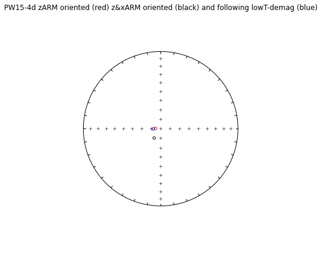

```python
fignum = 1
plt.figure(num=fignum,figsize=(6,6),dpi=160)
pmagplotlib.plotNET(fignum)
IPmag.iplotDI(zARM_oriented_directions,'r')
IPmag.iplotDI(zARMxARM_rotated_directions_prime,'k')
IPmag.iplotDI([[268.4,-82.3]],'b')
plt.title('PW15-4d zARM oriented (red) z&xARM oriented (black) and following lowT-demag (blue)');
plt.savefig('code_output/PW15-4d_eqarea_ARMex.svg')
```